# Problem set 2: Density dependence

# 1. Writing display and multiple lines of math in RMarkdown and $\LaTeX$

There are two ways of writing math in R, either inline or displayed. In-line is used when you want to write math that is simple and short, like if I wanted to write, $C = \tau r$, as the circumference of a circle in relation to its radius. ([See the Tau Manifesto](https://tauday.com/tau-manifesto).) ; For example, `$C = \tau r$` gives you what I just typed. This is what you did on last week’s problem set. To write displayed, use two dollar signs and write the math in the middle. Displayed math create a line break, which you use for more complex or important math; e.g.,
$$a^2 + b^2 = c^2.$$
To write math in display mode, you use two dollar signs; e.g., `$$a^2 + b^2 = c^2$$`. For different symbols, letters, etc. see the Resources page on the course website and follow the link to $\LaTeX$.

1.1 Using the $\LaTeX$ guide as a reference, take the solution from the continuous-time density-independent growth mode, $N_t = N_0e^{rt}$, and algebraically solve for $t$. For every algebraic step, please use a new line within $\LaTeX$ display mode, like if I wanted to express $E = mc^2$ in terms of the speed of light, $c$. Separate lines using `\\` and, to align the equations, use `\begin{aligned}` after the first pair of dollar signed and `\end{aligned}` before the second pair of dollar signed and put an `&` before each equals sign to align them, so they look something like this:
$$\begin{aligned}
E &= mc^2 \\
\frac{E}{m} &= c^2 \\
c^2 &= \frac{E}{m} \\
c &= \sqrt[2]{\frac{E}{m}}.
\end{aligned}$$

1.2. We’ll cover the concept of equilibrium later in the semester in greater detail next week. But it’s when the system (e.g., population) is not changing; i.e., where the rate of change is 0, or $0 = dN/dt$. For the logistic equation, $dN/dt = rN(K - N)/K$, turn it into a per-capita rate of change by dividing both sides by $N$, then find the equilibrium; i.e., set the per-capita rate of change to 0 and solve for $N$. For every algebraic step, please use a new line within $\LaTeX$ display mode, like above.

### Answers

> 1.1.
> $$\begin{aligned}
> N_t &= N_0e^{rt} \\
> \frac{N_t}{N_0} &= e^{rt} \\
> \log _e \left(\frac{N_t}{N_0}\right) &= rt \\
> \frac{\log _e \left(\frac{N_t}{N_0}\right)}{r} &= t \\
> t &= \frac{\log _e \left(\frac{N_t}{N_0}\right)}{r} \\
> \end{aligned}$$

> 1.2.
> $$\begin{aligned}
> \frac{dN}{dt} &= rN\left(\frac{K - N}{K}\right) \\
> \frac{1}{N}\frac{dN}{dt} &= r\left(\frac{K - N}{K}\right) \\
> 0 &= r\left(\frac{K - N}{K}\right) \\
> 0 &= r - \frac{r}{K}N \\
> \frac{r}{K}N &= r \\
> rN &= rK \\
> N^\ast = K
> \end{aligned}$$

# 2. Using `ode()` and some density-dependent models

In lab in week 3 I showed you the numerical solver you will be using for just about everything in the class. It is the function called `ode()` in the `deSolve` package.

2.1. For a logistic equation, $dN/dt = rN - \alpha N^2$, give $r$ and $\alpha$ whatever values you want, but include the values in your answer. Start at some low value of $N$, say 0.1 Please plot the time series. Then, again numerically ingrate across a few different initial population sizes, say where $N$ starts at 1/2 of equilibrium you chose,where $N$ starts just slightly about the equilibrium you chose, and where $N$ starts at a value that’s 25% higher than the equilibrium you chose. Plot these curves all on the same graph.

2.2. Last, recreate parts of the figure in [6.4.1](https://hankstevens.github.io/Primer-of-Ecology/05-DDgrowth.html#sec-discrete-logistic-growth) from Stevens. Choose a value of $r_d$ that gives you asymptotic stability (panel), oscillations (damped or perpetual; all the of panels but the first and last), and chaos (the last panel). Use the logistic equation he uses that is found 3 chunks above the plots where he creates `dlogistic`. Use the numerical solver, but in the `ode()` function, write the argument `method = "iteration"`. Use the logistic equation he uses in `dlogistic`, give the initial abundance a value of 10, set alpha to 0.01, and create a time sequence from 0 to 20.

Please create your own plots using base `plot()`. To make a 2-row-by-3-column figure, in a line above `plot()` add a line for a function that adjusts plotting parameters, `par()`. If you use the argument `mfrow` (stands for **m**atrix of **f**igures by **row**s; there’s also an `mfcol`) equal to the rows and columns, `c(2, 3)`, then the next 6 plots you make will be loaded in with the first 3 in the top row and the last 3 in the bottom row.

> 2.1.

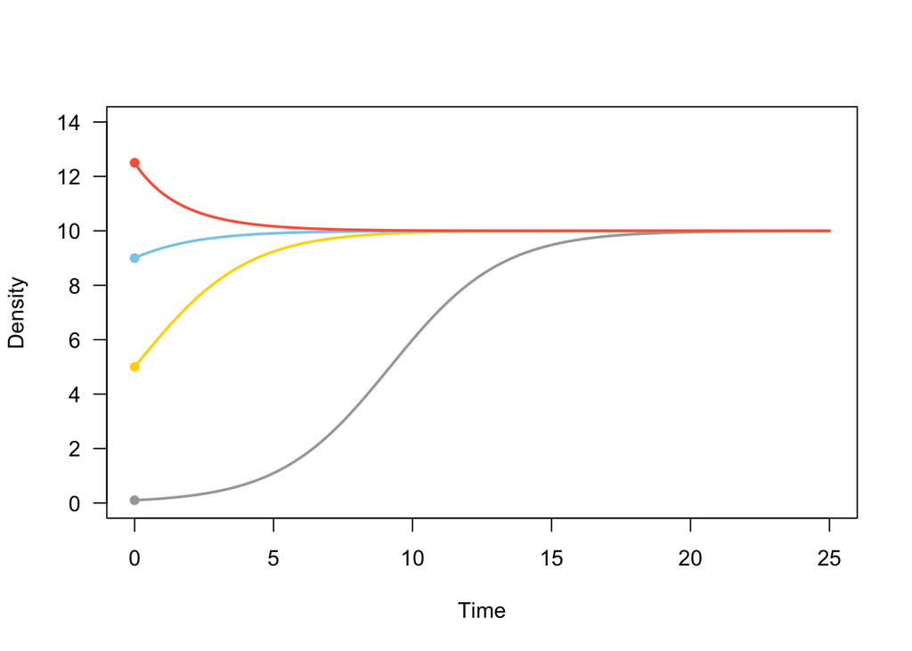

```r
# Load our pacakge deSolve
  library(package = "deSolve")

# Create the 4 objects we need to numerically solve our problem, but with four
# initial densities for the 4 initial conditions
  logistic <- function(time, state, pars) {
    with(as.list(c(state, pars)), {
      dN <- r*N - alpha*N^2
      return(list(c(dN)))
    })
  }

  yini1  <- c(N = 0.1)
  yini2  <- c(N = 5)
  yini3  <- c(N = 9)
  yini4  <- c(N = 12.5)

  pars  <- c(r = 0.5, alpha = 0.05)
  times <- seq(from = 0, to = 25, by = 0.1)

# Run our numerical solver 4 times, each with a different initial density
  out1   <- ode(y = yini1, times = times, func = logistic, parms = pars)
  out2   <- ode(y = yini2, times = times, func = logistic, parms = pars)
  out3   <- ode(y = yini3, times = times, func = logistic, parms = pars)
  out4   <- ode(y = yini4, times = times, func = logistic, parms = pars)

# Plot and ad lines
plot(x = out1[,1], y = out1[,2], xlab = "Time", ylab = "Density", type = "l", las = 1, ylim = c(0, 14), col = "grey66", lwd = 2)
  lines(x = out2[,1], y = out2[,2], col = "gold", lwd = 2)
  lines(x = out3[,1], y = out3[,2], col = "skyblue", lwd = 2)
  lines(x = out4[,1], y = out4[,2], col = "tomato", lwd = 2)

  # Sometimes I add points for funzies
  points(x = rep(x = 0, times = 4), y = c(yini1, yini2, yini3, yini4), col = c("grey66", "gold", "skyblue", "tomato"), pch = 16)
```

> 2.2.

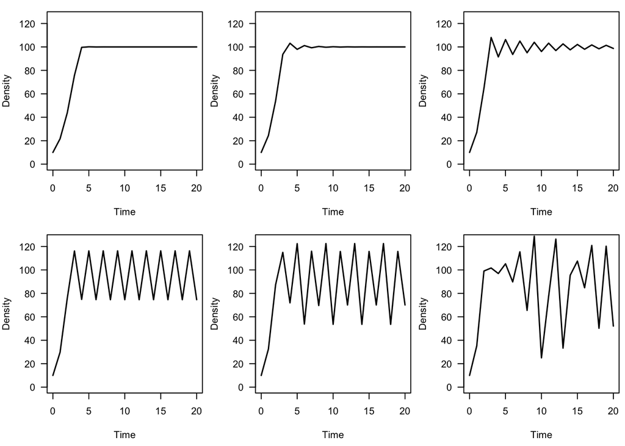

```r
dlogistic <- function(time, state, pars) {
  with(as.list(c(state, pars)), {
    dN <- N + rd*N*(1 - alpha*N) # Sorry, using "iteration" means you need to put a + N in your model
    return(list(c(dN)))
  })
}

yini  <- c(N = 10)
times <- 0:20

rd_vec <- seq(from = 1.3, to = 2.8, by = 0.3)
pars1  <- c(rd = rd_vec[1], alpha = 0.01)
pars2  <- c(rd = rd_vec[2], alpha = 0.01)
pars3  <- c(rd = rd_vec[3], alpha = 0.01)
pars4  <- c(rd = rd_vec[4], alpha = 0.01)
pars5  <- c(rd = rd_vec[5], alpha = 0.01)
pars6  <- c(rd = rd_vec[6], alpha = 0.01)

out1   <- ode(y = yini, times = times, func = dlogistic, parms = pars1, method = "iteration")
out2   <- ode(y = yini, times = times, func = dlogistic, parms = pars2, method = "iteration")
out3   <- ode(y = yini, times = times, func = dlogistic, parms = pars3, method = "iteration")
out4   <- ode(y = yini, times = times, func = dlogistic, parms = pars4, method = "iteration")
out5   <- ode(y = yini, times = times, func = dlogistic, parms = pars5, method = "iteration")
out6   <- ode(y = yini, times = times, func = dlogistic, parms = pars6, method = "iteration")

par(mfrow = c(2, 3), mar = c(4.5, 4, 1, 0.5)) # mar changes the amount of space below, left, top, and right of each plot
plot(x = out1[,1], y = out1[,2], xlab = "Time", ylab = "Density", type = "l", las = 1, ylim = c(0, 125), lwd = 1.5)
plot(x = out2[,1], y = out2[,2], xlab = "Time", ylab = "Density", type = "l", las = 1, ylim = c(0, 125), lwd = 1.5)
plot(x = out3[,1], y = out3[,2], xlab = "Time", ylab = "Density", type = "l", las = 1, ylim = c(0, 125), lwd = 1.5)
plot(x = out4[,1], y = out4[,2], xlab = "Time", ylab = "Density", type = "l", las = 1, ylim = c(0, 125), lwd = 1.5)
plot(x = out5[,1], y = out5[,2], xlab = "Time", ylab = "Density", type = "l", las = 1, ylim = c(0, 125), lwd = 1.5)
plot(x = out6[,1], y = out6[,2], xlab = "Time", ylab = "Density", type = "l", las = 1, ylim = c(0, 125), lwd = 1.5)
```